# Jorge de Andrés González

# Ejercicio 1

## Enunciado

Considere la base de datos “ehd” incluída en la librería “psy”.

Busque en la documentación la información asociada a cada una de las variables y realice un resumen sumario de la misma.

Se considera evaluar la varianza común de los datos utilizando el método de máxima verosimilitud. Si los datos son adecuados, determine el número ideal de factores a obtener, realice el análisis e interprete los factores finalmente obtenidos.

## Importación de datos

```r
library(psy)
data(ehd)
str(ehd)
```

```
## 'data.frame':    269 obs. of  20 variables:
##  $ e1 : int  0 2 3 3 3 3 4 2 4 3 ...
##  $ e2 : int  2 2 0 2 0 0 3 0 0 0 ...
##  $ e3 : int  0 2 3 2 0 0 0 0 0 0 ...
##  $ e4 : int  0 0 0 0 2 3 3 4 3 3 ...
##  $ e5 : int  0 0 0 0 0 3 0 3 2 2 ...
##  $ e6 : int  0 0 0 0 2 2 0 3 0 0 ...
##  $ e7 : int  0 3 0 2 2 0 2 0 2 0 ...
##  $ e8 : int  2 0 0 0 2 0 0 0 0 0 ...
##  $ e9 : int  0 3 0 1 2 0 0 0 0 0 ...
##  $ e10: int  2 0 1 2 2 0 0 0 2 2 ...
##  $ e11: int  0 4 3 3 4 3 4 4 4 3 ...
##  $ e12: int  2 0 3 2 2 3 4 2 4 3 ...
##  $ e13: int  0 4 3 3 4 3 4 4 4 3 ...
##  $ e14: int  0 4 0 0 0 0 3 3 0 0 ...
##  $ e15: int  0 0 3 3 4 3 0 0 2 2 ...
##  $ e16: int  0 0 0 0 0 0 3 4 0 3 ...
##  $ e17: int  0 0 0 2 0 0 3 4 4 3 ...
##  $ e18: int  3 0 2 3 3 2 0 0 3 3 ...
##  $ e19: int  0 0 3 3 3 3 0 2 3 3 ...
##  $ e20: int  0 0 0 3 3 3 0 0 0 2 ...
```

## Realización de resumen sumario

```r
summary(ehd)
```

```
##        e1              e2              e3               e4
##  Min.   :0.000   Min.   :0.000   Min.   :0.0000   Min.   :0.000
##  1st Qu.:1.000   1st Qu.:0.000   1st Qu.:0.0000   1st Qu.:0.000
##  Median :3.000   Median :1.000   Median :0.0000   Median :2.000
##  Mean   :2.242   Mean   :1.301   Mean   :0.5799   Mean   :1.561
##  3rd Qu.:3.000   3rd Qu.:3.000   3rd Qu.:0.0000   3rd Qu.:3.000
##  Max.   :4.000   Max.   :4.000   Max.   :4.0000   Max.   :4.000
##        e5               e6               e7              e8
##  Min.   :0.0000   Min.   :0.0000   Min.   :0.000   Min.   :0.0000
##  1st Qu.:0.0000   1st Qu.:0.0000   1st Qu.:0.000   1st Qu.:0.0000
##  Median :0.0000   Median :0.0000   Median :0.000   Median :0.0000
##  Mean   :0.9628   Mean   :0.5985   Mean   :1.089   Mean   :0.8773
##  3rd Qu.:2.0000   3rd Qu.:1.0000   3rd Qu.:2.000   3rd Qu.:2.0000
##  Max.   :4.0000   Max.   :4.0000   Max.   :4.000   Max.   :4.0000
##        e9              e10             e11             e12
##  Min.   :0.0000   Min.   :0.000   Min.   :0.000   Min.   :0.000
##  1st Qu.:0.0000   1st Qu.:0.000   1st Qu.:1.000   1st Qu.:1.000
##  Median :0.0000   Median :2.000   Median :3.000   Median :2.000
##  Mean   :0.3346   Mean   :1.569   Mean   :2.253   Mean   :2.104
##  3rd Qu.:0.0000   3rd Qu.:2.000   3rd Qu.:3.000   3rd Qu.:3.000
##  Max.   :4.0000   Max.   :4.000   Max.   :4.000   Max.   :4.000
##       e13             e14              e15             e16
##  Min.   :0.000   Min.   :0.0000   Min.   :0.000   Min.   :0.0000
##  1st Qu.:1.000   1st Qu.:0.0000   1st Qu.:0.000   1st Qu.:0.0000
##  Median :2.000   Median :0.0000   Median :2.000   Median :0.0000
##  Mean   :2.138   Mean   :0.5056   Mean   :1.777   Mean   :0.9108
##  3rd Qu.:3.000   3rd Qu.:0.0000   3rd Qu.:3.000   3rd Qu.:2.0000
##  Max.   :4.000   Max.   :4.0000   Max.   :4.000   Max.   :4.0000
##       e17             e18             e19             e20
##  Min.   :0.000   Min.   :0.000   Min.   :0.000   Min.   :0.0000
##  1st Qu.:0.000   1st Qu.:0.000   1st Qu.:0.000   1st Qu.:0.0000
##  Median :0.000   Median :2.000   Median :2.000   Median :0.0000
##  Mean   :1.115   Mean   :1.703   Mean   :1.506   Mean   :0.8662
##  3rd Qu.:2.000   3rd Qu.:3.000   3rd Qu.:3.000   3rd Qu.:2.0000
##  Max.   :4.000   Max.   :4.000   Max.   :4.000   Max.   :4.0000
```

Se puede observar como todas las variables son categóricas entre 0 y 4. Como no están en string, no hace falta transformarlas a número.

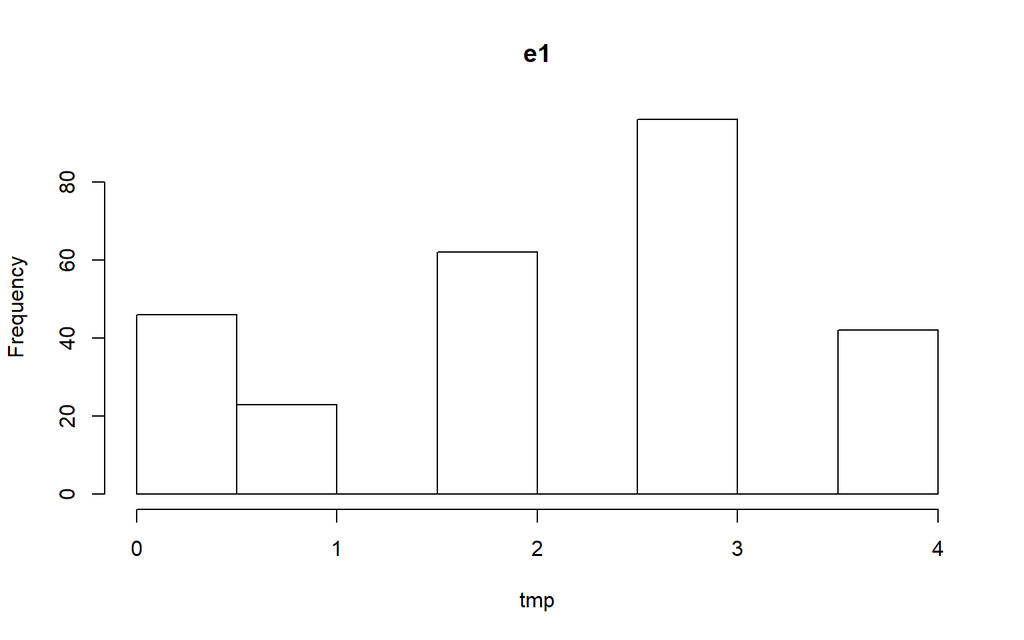

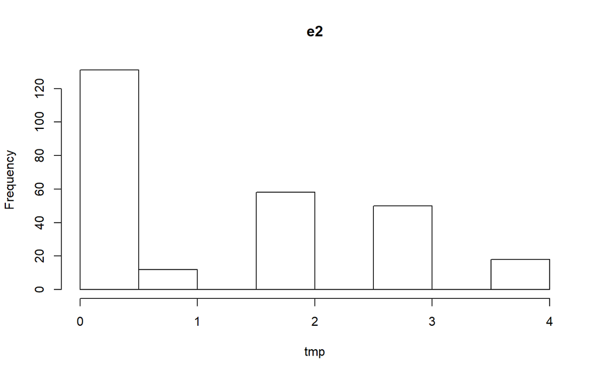

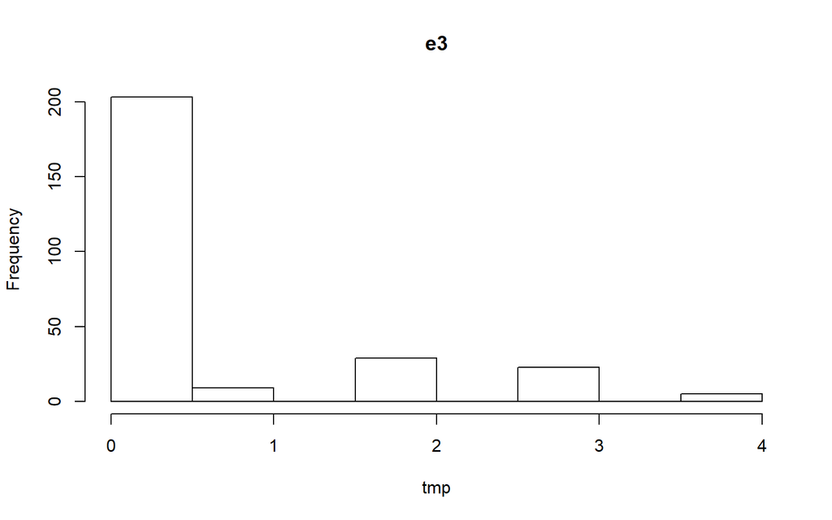

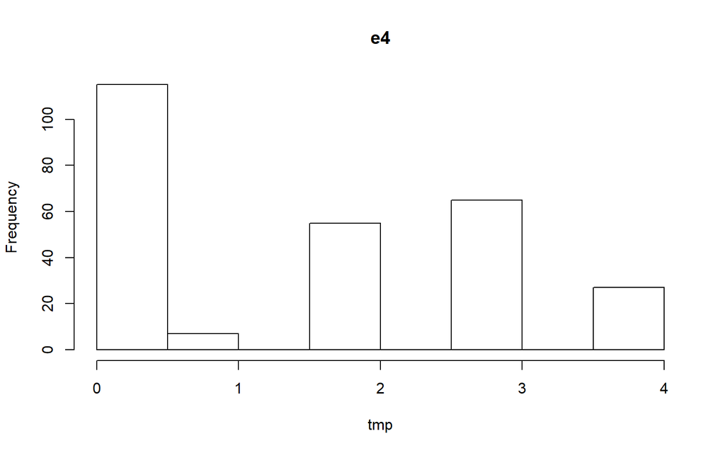

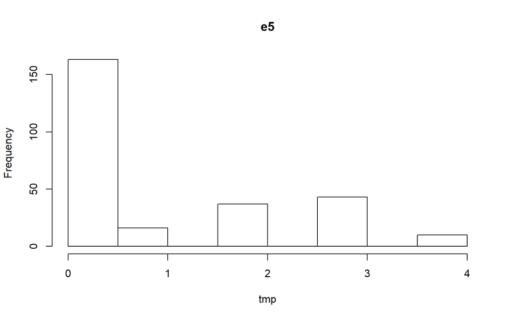

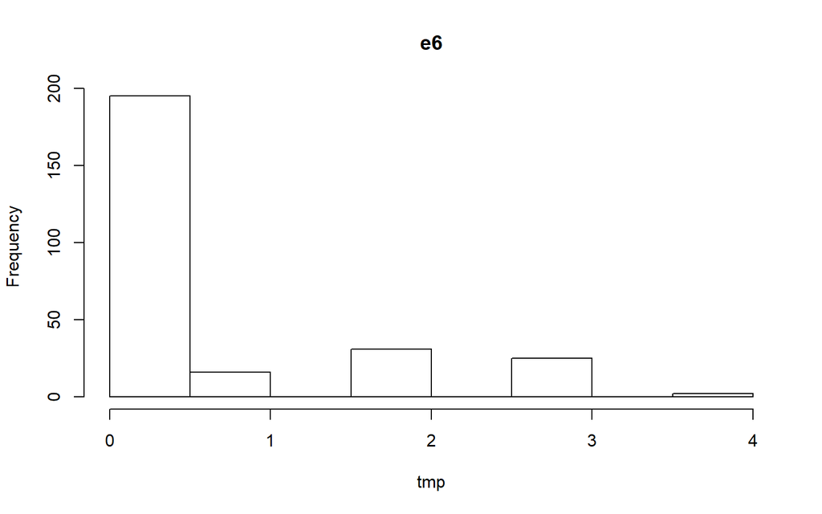

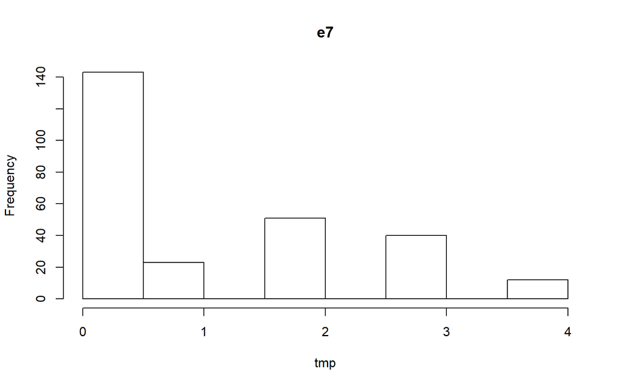

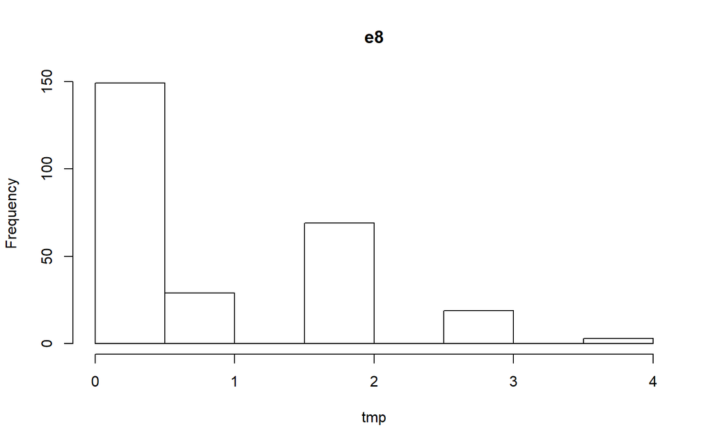

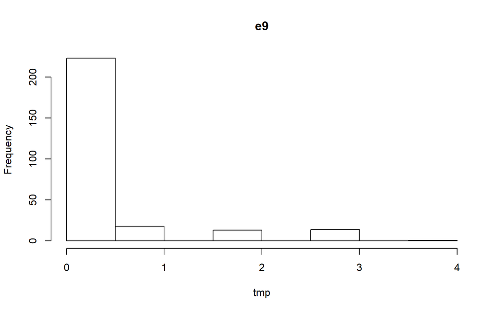

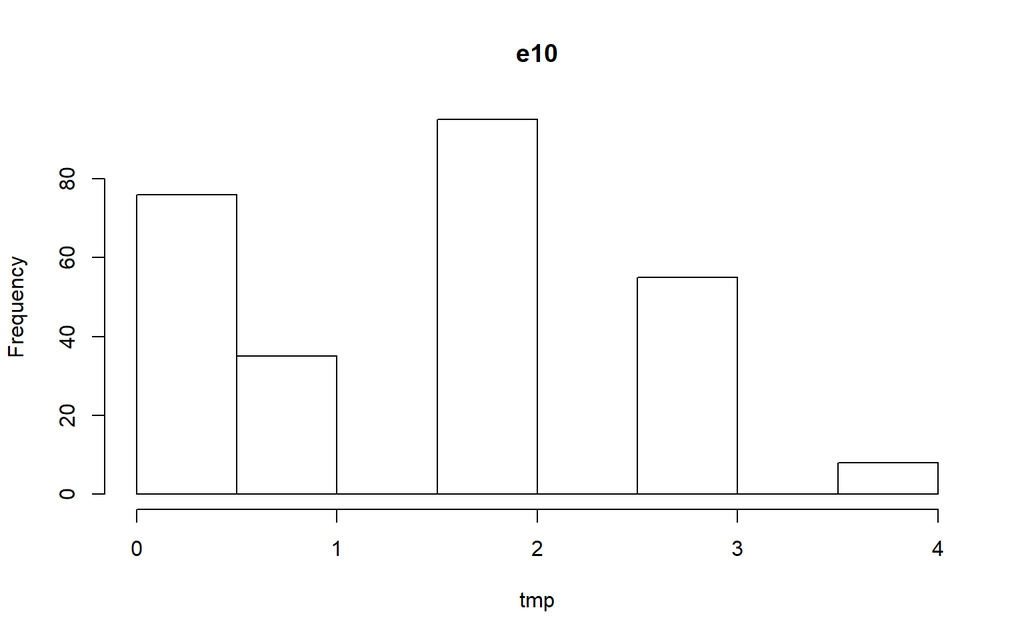

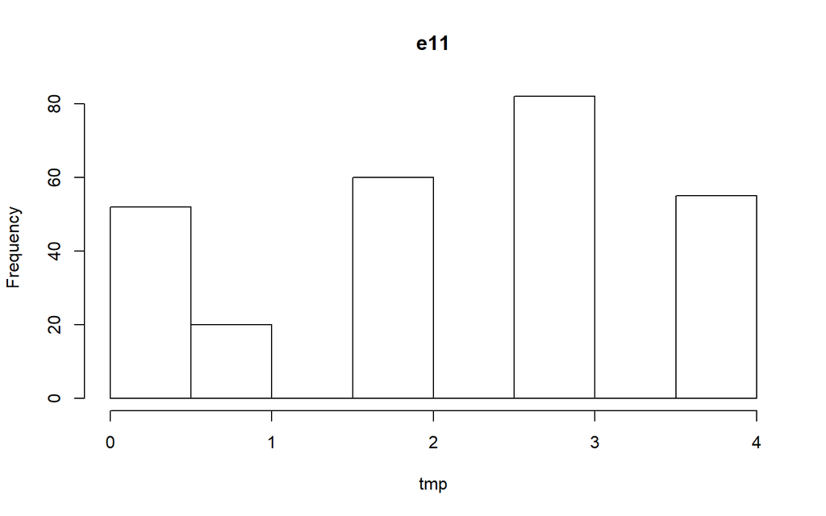

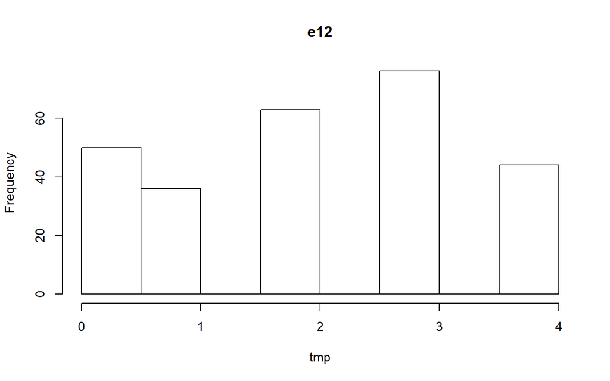

[8 more figures not shown]

```r
for (x in colnames(ehd))
{
  tmp <- ehd[[x]]
  hist(tmp, main=x)
}
```

## Realización AF

### Comprobación Datos

```r
table(is.na(ehd))
```

```
##
## FALSE
##  5380
```

No existen datos nulos, y todos los datos están entre 0 y 4, por lo que parece ser que los datos son adecuados.

### Creación modelo AF

Creamos un modelo de Análisis Factorial puesto que se desea un análisis de la varianza común.

```r
library(corrplot)
correl <- cor(ehd, method="spearman")
correl
```

```
##              e1          e2          e3           e4          e5           e6
## e1   1.00000000  0.23945531 -0.05841165  0.319885596  0.21111440  0.154087633
## e2   0.23945531  1.00000000  0.50662127 -0.476373564 -0.49092579 -0.425372613
## e3  -0.05841165  0.50662127  1.00000000 -0.579877866 -0.39352228 -0.328342027
## e4   0.31988560 -0.47637356 -0.57987787  1.000000000  0.70675058  0.599369820
## e5   0.21111440 -0.49092579 -0.39352228  0.706750578  1.00000000  0.730321529
## e6   0.15408763 -0.42537261 -0.32834203  0.599369820  0.73032153  1.000000000
## e7   0.34095374  0.56069393  0.38241702 -0.259371739 -0.21616773 -0.261415694
## e8   0.05489755  0.22602596  0.13835392 -0.252565730 -0.26571858 -0.242640357
## e9   0.01904877  0.25475807  0.35712737 -0.186659887 -0.12544905 -0.064689078
## e10  0.42438610  0.33490400  0.03854660  0.002051976 -0.05674871  0.002450781
## e11  0.61926518  0.05903842 -0.08809992  0.369892430  0.36309250  0.256481823
## e12  0.68005090  0.35622123  0.07058637  0.059604290 -0.02638953 -0.027313585
## e13  0.56028217  0.04366561 -0.03716364  0.283961688  0.23345355  0.176460766
## e14  0.12796437 -0.17852177 -0.15884507  0.327875166  0.28268793  0.290969592
## e15  0.27147678  0.29247366  0.23798053 -0.159282261 -0.14797188 -0.145434748
## e16  0.30762584 -0.02201983 -0.14312606  0.318509003  0.20688818  0.178780011
## e17  0.28719600 -0.18880867 -0.24412774  0.476131622  0.42029163  0.346652969
## e18  0.31104721  0.40055276  0.23393412 -0.247756455 -0.32889327 -0.241190541
## e19  0.20192242  0.25206014  0.24102584 -0.201506114 -0.18864809 -0.127168280
## e20  0.07612886  0.25587222  0.26191931 -0.202248814 -0.20348308 -0.167926751
##              e7          e8            e9          e10         e11
## e1   0.34095374  0.05489755  0.0190487712  0.424386100  0.61926518
## e2   0.56069393  0.22602596  0.2547580726  0.334904000  0.05903842
## e3   0.38241702  0.13835392  0.3571273722  0.038546602 -0.08809992
## e4  -0.25937174 -0.25256573 -0.1866598875  0.002051976  0.36989243
## e5  -0.21616773 -0.26571858 -0.1254490502 -0.056748710  0.36309250
## e6  -0.26141569 -0.24264036 -0.0646890780  0.002450781  0.25648182
## e7   1.00000000  0.17554915  0.3456596086  0.209165125  0.20943510
## e8   0.17554915  1.00000000  0.2148376307  0.257306284 -0.05234906
## e9   0.34565961  0.21483763  1.0000000000 -0.022808145  0.11528332
## e10  0.20916513  0.25730628 -0.0228081450  1.000000000  0.14262219
## e11  0.20943510 -0.05234906  0.1152833153  0.142622185  1.00000000
## e12  0.39051985  0.03240983 -0.0007440794  0.374704685  0.46724774
## e13  0.15966591 -0.03354326  0.0960011805  0.153063898  0.83108764
## e14 -0.15481408 -0.24989948 -0.0839084634 -0.105989455  0.31464747
## e15  0.27019889  0.22201567  0.2585207015  0.263235060  0.22342617
## e16 -0.08578229 -0.14221897 -0.0269065442  0.008486817  0.39786328
## e17 -0.07963666 -0.23290432 -0.0933794704 -0.027826671  0.39912002
## e18  0.38325595  0.19922812  0.1116795687  0.325960861  0.09497772
```

[output cut: 29 more lines]

```
## e6   0.34665297 -0.24119054 -0.12716828 -0.16792675
## e7  -0.07963666  0.38325595  0.21555173  0.15162590
## e8  -0.23290432  0.19922812  0.15700253  0.18478176
## e9  -0.09337947  0.11167957  0.28648104  0.25737011
## e10 -0.02782667  0.32596086  0.21604542  0.11398269
## e11  0.39912002  0.09497772  0.17713738  0.09036367
## e12  0.15102043  0.40347193  0.21879846  0.09751977
## e13  0.40396202  0.11852331  0.19210091  0.11766959
## e14  0.44796597 -0.31068857 -0.31811692 -0.29253404
## e15 -0.23008521  0.58419072  0.65363114  0.52246383
## e16  0.31986410 -0.07914559 -0.06039098 -0.06104187
## e17  1.00000000 -0.19329002 -0.20913020 -0.24882879
## e18 -0.19329002  1.00000000  0.47339100  0.42470829
## e19 -0.20913020  0.47339100  1.00000000  0.70007286
## e20 -0.24882879  0.42470829  0.70007286  1.00000000
```

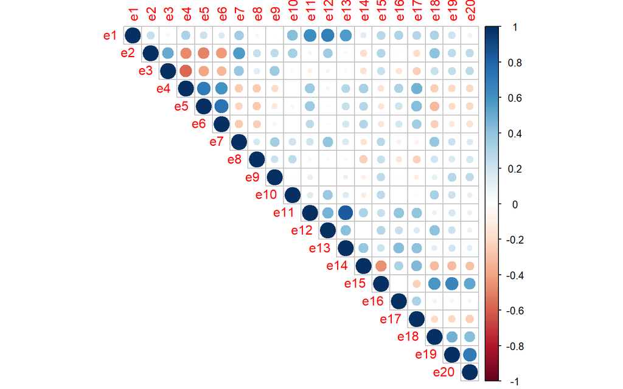

```r
corrplot(correl, type="upper")
```

Como podemos observar en la matriz de correlaciones, y como es de esperar, la diagonal (la variable consigo misma) tiene una correlación de 1. Muchas variables no tienen correlación entre sí, aunque existen algunas que sí la poseen.

```r
library(psych)
cortest.bartlett(ehd)
```

```
## R was not square, finding R from data
```

```
## $chisq
## [1] 2788.754
##
## $p.value
## [1] 0
##
## $df
## [1] 190
```

Tras la prueba de esfericidad de Bartlett, podemos obtener que existen correlaciones significativas entre las variables, y por lo tanto el modelo factorial tiene sentido en este caso.

```r
det(correl)
```

```
## [1] 2.607629e-05
```

```r
pc.1 <- princomp(ehd, cor=TRUE)
summary(pc.1, loadings=TRUE)
```

```
## Importance of components:
##                           Comp.1    Comp.2     Comp.3     Comp.4     Comp.5
## Standard deviation     2.2702527 2.0386730 1.31838590 1.20433682 1.05483400
## Proportion of Variance 0.2577024 0.2078094 0.08690707 0.07252136 0.05563374
## Cumulative Proportion  0.2577024 0.4655117 0.55241881 0.62494017 0.68057391
##                            Comp.6     Comp.7     Comp.8     Comp.9    Comp.10
## Standard deviation     0.96744644 0.83211816 0.83026398 0.74361239 0.71993183
## Proportion of Variance 0.04679763 0.03462103 0.03446691 0.02764797 0.02591509
## Cumulative Proportion  0.72737154 0.76199257 0.79645948 0.82410745 0.85002255
##                           Comp.11    Comp.12    Comp.13    Comp.14    Comp.15
## Standard deviation     0.67843676 0.66636165 0.64227235 0.57381716 0.55011015
## Proportion of Variance 0.02301382 0.02220189 0.02062569 0.01646331 0.01513106
## Cumulative Proportion  0.87303637 0.89523826 0.91586395 0.93232725 0.94745831
##                           Comp.16    Comp.17    Comp.18     Comp.19     Comp.20
## Standard deviation     0.53289913 0.49334109 0.45205952 0.435273436 0.360063951
## Proportion of Variance 0.01419907 0.01216927 0.01021789 0.009473148 0.006482302
## Cumulative Proportion  0.96165739 0.97382666 0.98404455 0.993517698 1.000000000
##
## Loadings:
##     Comp.1 Comp.2 Comp.3 Comp.4 Comp.5 Comp.6 Comp.7 Comp.8 Comp.9 Comp.10
## e1          0.417         0.199  0.102                              0.114
## e2   0.307         0.327                      -0.250  0.114         0.173
## e3   0.260         0.297 -0.293  0.125  0.196 -0.261         0.228 -0.476
## e4  -0.305  0.206 -0.211         0.146                      -0.223  0.244
## e5  -0.299  0.173 -0.195 -0.124  0.371  0.152                0.105
## e6  -0.264  0.155 -0.220 -0.135  0.376  0.156 -0.275  0.115  0.148 -0.179
## e7   0.245  0.143  0.305         0.300  0.296  0.314        -0.102  0.271
## e8   0.197                       0.362 -0.734  0.270        -0.114 -0.161
## e9   0.185         0.103 -0.554  0.323                0.146 -0.161  0.204
## e10  0.135  0.189         0.430  0.283 -0.248 -0.577
## e11         0.421        -0.121                0.202 -0.150  0.327
## e12  0.113  0.334  0.128  0.297         0.194
## e13         0.401        -0.143 -0.207 -0.214  0.134 -0.222  0.273 -0.125
## e14 -0.243  0.130  0.339 -0.205 -0.135 -0.137 -0.274 -0.374
## e15  0.272  0.179 -0.349                       0.150  0.193        -0.312
## e16 -0.122  0.237  0.116        -0.360 -0.227 -0.154  0.769 -0.105
## e17 -0.237  0.218  0.173                             -0.142 -0.690 -0.420
## e18  0.286  0.153 -0.151  0.174 -0.109  0.203               -0.295 -0.299
## e19  0.264  0.158 -0.363 -0.215 -0.136        -0.171 -0.123
## e20  0.252  0.108 -0.320 -0.286 -0.173        -0.240 -0.200 -0.192  0.307
```

[output cut: 27 more lines]

```
## e6
## e7
## e8
## e9
## e10
## e11  0.660
## e12 -0.106
## e13 -0.635
## e14
## e15
## e16
## e17
## e18
## e19
## e20
```

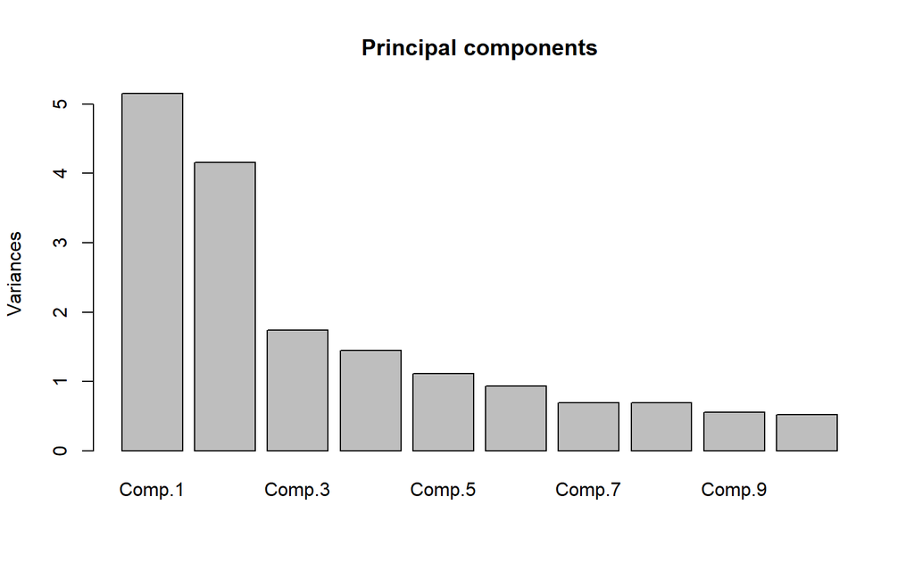

```r
plot(pc.1, main="Principal components")
```

```r
pc.1.ps <- fa(correl, n.obs = length(ehd), fm = "ml", nfactors = 7, rotate ="varimax")
print(pc.1.ps)
```

```
## Factor Analysis using method =  ml
## Call: fa(r = correl, nfactors = 7, n.obs = length(ehd), rotate = "varimax",
##     fm = "ml")
## Standardized loadings (pattern matrix) based upon correlation matrix
##       ML2   ML3   ML4   ML5   ML6   ML1   ML7   h2    u2 com
## e1   0.46  0.18  0.13  0.69 -0.01  0.20  0.00 0.78 0.224 2.2
## e2  -0.03 -0.43  0.12  0.41  0.50  0.22 -0.03 0.67 0.328 3.5
## e3  -0.09 -0.32  0.14  0.02  0.67  0.03  0.00 0.58 0.423 1.6
## e4   0.29  0.66 -0.10  0.10 -0.43 -0.03 -0.08 0.73 0.266 2.3
## e5   0.21  0.90 -0.13 -0.03 -0.12 -0.05  0.02 0.88 0.119 1.2
## e6   0.16  0.75 -0.06 -0.07 -0.13  0.02 -0.10 0.62 0.378 1.2
## e7   0.07 -0.16  0.07  0.47  0.52  0.07  0.13 0.55 0.447 2.4
## e8  -0.08 -0.22  0.13  0.04  0.12  0.24  0.21 0.19 0.805 4.4
## e9   0.04 -0.02  0.23 -0.01  0.49 -0.05  0.04 0.30 0.702 1.5
## e10  0.04  0.00  0.13  0.29 -0.02  0.95  0.02 1.00 0.005 1.2
## e11  0.78  0.26  0.13  0.28  0.10  0.01  0.07 0.79 0.207 1.6
## e12  0.32 -0.05  0.13  0.70  0.04  0.15  0.02 0.64 0.356 1.6
## e13  0.96  0.08  0.15  0.10  0.07  0.07  0.06 0.97 0.032 1.1
## e14  0.49  0.16 -0.35 -0.11 -0.03 -0.04 -0.49 0.65 0.349 3.2
## e15  0.06 -0.06  0.69  0.22  0.15  0.11  0.39 0.71 0.286 2.1
## e16  0.45  0.12 -0.04  0.14 -0.12 -0.05 -0.12 0.27 0.731 1.7
## e17  0.45  0.33 -0.23  0.10 -0.12 -0.05 -0.21 0.43 0.571 3.3
## e18  0.00 -0.26  0.48  0.40  0.10  0.16  0.17 0.52 0.479 3.2
## e19  0.04 -0.07  0.86  0.09  0.16  0.09  0.01 0.79 0.213 1.1
## e20  0.00 -0.10  0.76  0.00  0.18  0.02 -0.02 0.63 0.374 1.2
##
##                        ML2  ML3  ML4  ML5  ML6  ML1  ML7
## SS loadings           2.68 2.50 2.42 1.81 1.58 1.14 0.58
## Proportion Var        0.13 0.13 0.12 0.09 0.08 0.06 0.03
## Cumulative Var        0.13 0.26 0.38 0.47 0.55 0.61 0.64
## Proportion Explained  0.21 0.20 0.19 0.14 0.12 0.09 0.05
## Cumulative Proportion 0.21 0.41 0.60 0.74 0.87 0.95 1.00
##
## Mean item complexity =  2.1
## Test of the hypothesis that 7 factors are sufficient.
##
## The degrees of freedom for the null model are  190  and the objective function was  10.55 with Chi Square of  121.38
## The degrees of freedom for the model are 71  and the objective function was  0.44
##
## The root mean square of the residuals (RMSR) is  0.02
## The df corrected root mean square of the residuals is  0.03
##
## The harmonic number of observations is  20 with the empirical chi square  3.48  with prob <  1
## The total number of observations was  20  with Likelihood Chi Square =  2.98  with prob <  1
##
## Tucker Lewis Index of factoring reliability =  -0.544
## RMSEA index =  0  and the 90 % confidence intervals are  0 0
## BIC =  -209.72
## Fit based upon off diagonal values = 0.99
## Measures of factor score adequacy
##                                                    ML2  ML3  ML4  ML5  ML6  ML1
## Correlation of (regression) scores with factors   0.98 0.94 0.92 0.89 0.84 0.99
## Multiple R square of scores with factors          0.96 0.88 0.85 0.79 0.71 0.97
## Minimum correlation of possible factor scores     0.92 0.77 0.69 0.57 0.42 0.95
##                                                    ML7
## Correlation of (regression) scores with factors   0.74
## Multiple R square of scores with factors          0.55
## Minimum correlation of possible factor scores     0.10
```

Usamos la librería Factanal a continuación, para tener otra manera de calcular con máxima verosimilitud:

```r
fact.1 <- factanal(ehd, factors=7, rotation="varimax", scores = "Bartlett")
fact.1
```

```
##
## Call:
## factanal(x = ehd, factors = 7, scores = "Bartlett", rotation = "varimax")
##
## Uniquenesses:
##    e1    e2    e3    e4    e5    e6    e7    e8    e9   e10   e11   e12   e13
## 0.208 0.342 0.443 0.294 0.098 0.384 0.400 0.778 0.574 0.005 0.204 0.359 0.038
##   e14   e15   e16   e17   e18   e19   e20
## 0.317 0.299 0.728 0.552 0.481 0.181 0.395
##
## Loadings:
##     Factor1 Factor2 Factor3 Factor4 Factor5 Factor6 Factor7
## e1   0.499   0.214   0.123           0.664   0.203
## e2          -0.394   0.115   0.538   0.374   0.243
## e3          -0.273   0.117   0.676
## e4   0.274   0.646  -0.112  -0.423   0.109
## e5   0.193   0.910  -0.135  -0.122
## e6   0.154   0.745          -0.139
## e7          -0.138           0.583   0.460           0.139
## e8          -0.171   0.148   0.212           0.265   0.231
## e9                   0.256   0.594
## e10                  0.125           0.277   0.948
## e11  0.797   0.250   0.154           0.259
## e12  0.336           0.135           0.693   0.158
## e13  0.953           0.158
## e14  0.492   0.169  -0.337          -0.130          -0.527
## e15                  0.668   0.122   0.212   0.108   0.416
## e16  0.450   0.113          -0.120   0.132          -0.144
## e17  0.438   0.337  -0.224  -0.112                  -0.255
## e18         -0.255   0.468   0.114   0.397   0.145   0.210
## e19                  0.880   0.153
## e20         -0.105   0.742   0.203
##
##                Factor1 Factor2 Factor3 Factor4 Factor5 Factor6 Factor7
## SS loadings      2.703   2.432   2.405   1.827   1.704   1.166   0.683
## Proportion Var   0.135   0.122   0.120   0.091   0.085   0.058   0.034
## Cumulative Var   0.135   0.257   0.377   0.468   0.554   0.612   0.646
##
## Test of the hypothesis that 7 factors are sufficient.
## The chi square statistic is 103.45 on 71 degrees of freedom.
## The p-value is 0.00721
```

Cargas rotadas:

```r
sedim.1 <- varimax(fact.1$loadings)
sedim.1
```

```
## $loadings
##
## Loadings:
##     Factor1 Factor2 Factor3 Factor4 Factor5 Factor6 Factor7
## e1   0.499   0.215   0.123           0.664   0.203
## e2          -0.394   0.115   0.538   0.374   0.243
## e3          -0.272   0.117   0.676
## e4   0.273   0.646  -0.112  -0.423   0.110
## e5   0.193   0.910  -0.135  -0.122
## e6   0.154   0.745          -0.139
## e7          -0.138           0.584   0.459           0.139
## e8          -0.171   0.147   0.212           0.265   0.232
## e9                   0.256   0.594
## e10                  0.125           0.277   0.948
## e11  0.797   0.251   0.153           0.259
## e12  0.336           0.135           0.693   0.158
## e13  0.953           0.157
## e14  0.490   0.169  -0.336          -0.129          -0.529
## e15                  0.667   0.122   0.212   0.107   0.417
## e16  0.449   0.113          -0.120   0.133          -0.145
## e17  0.438   0.337  -0.224  -0.113                  -0.257
## e18         -0.255   0.467   0.114   0.397   0.145   0.212
## e19                  0.880   0.153
## e20         -0.105   0.742   0.202
##
##                Factor1 Factor2 Factor3 Factor4 Factor5 Factor6 Factor7
## SS loadings      2.701   2.433   2.401   1.827   1.704   1.165   0.689
## Proportion Var   0.135   0.122   0.120   0.091   0.085   0.058   0.034
## Cumulative Var   0.135   0.257   0.377   0.468   0.553   0.612   0.646
##
## $rotmat
##               [,1]          [,2]          [,3]          [,4]          [,5]
## [1,]  9.999967e-01  1.539743e-04 -1.125978e-04 -6.390194e-05  2.559279e-04
## [2,] -1.542769e-04  1.000000e+00  9.276972e-05 -1.037461e-04 -1.496011e-05
## [3,]  1.184758e-04 -9.248983e-05  9.999971e-01 -2.725067e-04  4.512326e-04
## [4,]  6.275502e-05  1.036619e-04  2.739205e-04  9.999997e-01 -5.104040e-04
## [5,] -2.525133e-04  1.517955e-05 -4.541995e-04  5.112138e-04  9.999988e-01
## [6,]  5.216889e-05 -5.271147e-06 -5.531460e-05  4.354149e-05  1.178667e-04
## [7,]  2.562027e-03  1.216783e-04 -2.339033e-03  5.034373e-04 -1.344250e-03
##               [,6]          [,7]
## [1,] -5.129396e-05 -0.0025619607
## [2,]  5.333483e-06 -0.0001210329
## [3,]  5.443770e-05  0.0023395133
## [4,] -4.329047e-05 -0.0005036749
## [5,] -1.183767e-04  0.0013435418
## [6,]  9.999999e-01  0.0003542446
## [7,] -3.543680e-04  0.9999928820
```

Finalmente, obtenemos el gráfico de sedimentación con las cargas ya rotadas

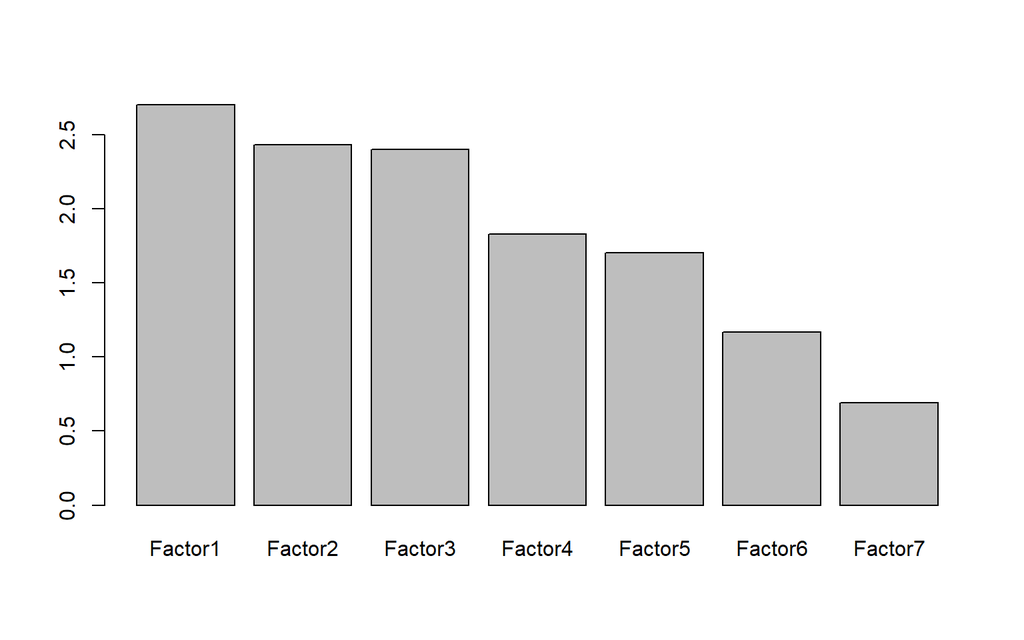

```r
barplot(sort(colSums(loadings(sedim.1) ^ 2), decreasing=TRUE))
```

# Ejercicio 2

## Enunciado

El fichero “socioecconomica.xlsx” contiene información sobre la evolución del paro en la provincia de Cantabria desde el año 2005 hasta el primer trimestre de 2020. Seleccione las tasas de paro y evalúe la similitud en la evolución de las series a través de un escalamiento multidimensional no métrico. Una vez reducida la dimensionalidad, realice un cluster agrupando las series que presenten comportamientos similares y establezca las conclusiones oportunas.

# Ejercicio 3

## Enunciado

El archivo “coffe.sav” contiene datos relativos a las imágen percibida de seis marcas de café helado. Para cada uno de los 23 atributos de imagen de café helado, los encuestados seleccionaron todas las marcas que quedaban descritas por el atributo. Las seis marcas se denotan AA, BB, CC, DD, EE y FF para mantener la confidencialidad. Analice la percepción asociada a las diferentes marcas.

# Ejercicio 4

## Enunciado

La base de datos Cars93 incluida en la librería “MASS” contiene una selección aleatoria de 93 modelos de automóviles de pasajeros de 1993 que se enumeraron tanto en la edición de Consumer Reports como en la Guía de compras de PACE. Las camionetas y los vehículos deportivos / utilitarios fueron eliminados debido a la información incompleta en la fuente de Consumer Reports. Los modelos duplicados (por ejemplo, Dodge Shadow y Plymouth Sundance) se enumeraron como máximo una vez. Plantee un análisis de correlación canónica entre las variables asociadas a las características físicas de los vehículos (tamaño de motor, caballos de fuerza, longitud, distancia entre ejes, anchura, asiento trasero y peso) y las relativas al precio y el funcionamiento (precio medio, consumo en ciudad, consumo en carretera y espacio de giro en U).

## Importación de datos

```r
library(MASS)
str(Cars93)
```

```
## 'data.frame':    93 obs. of  27 variables:
##  $ Manufacturer      : Factor w/ 32 levels "Acura","Audi",..: 1 1 2 2 3 4 4 4 4 5 ...
##  $ Model             : Factor w/ 93 levels "100","190E","240",..: 49 56 9 1 6 24 54 74 73 35 ...
##  $ Type              : Factor w/ 6 levels "Compact","Large",..: 4 3 1 3 3 3 2 2 3 2 ...
##  $ Min.Price         : num  12.9 29.2 25.9 30.8 23.7 14.2 19.9 22.6 26.3 33 ...
##  $ Price             : num  15.9 33.9 29.1 37.7 30 15.7 20.8 23.7 26.3 34.7 ...
##  $ Max.Price         : num  18.8 38.7 32.3 44.6 36.2 17.3 21.7 24.9 26.3 36.3 ...
##  $ MPG.city          : int  25 18 20 19 22 22 19 16 19 16 ...
##  $ MPG.highway       : int  31 25 26 26 30 31 28 25 27 25 ...
##  $ AirBags           : Factor w/ 3 levels "Driver & Passenger",..: 3 1 2 1 2 2 2 2 2 2 ...
##  $ DriveTrain        : Factor w/ 3 levels "4WD","Front",..: 2 2 2 2 3 2 2 3 2 2 ...
##  $ Cylinders         : Factor w/ 6 levels "3","4","5","6",..: 2 4 4 4 2 2 4 4 4 5 ...
##  $ EngineSize        : num  1.8 3.2 2.8 2.8 3.5 2.2 3.8 5.7 3.8 4.9 ...
##  $ Horsepower        : int  140 200 172 172 208 110 170 180 170 200 ...
##  $ RPM               : int  6300 5500 5500 5500 5700 5200 4800 4000 4800 4100 ...
##  $ Rev.per.mile      : int  2890 2335 2280 2535 2545 2565 1570 1320 1690 1510 ...
##  $ Man.trans.avail   : Factor w/ 2 levels "No","Yes": 2 2 2 2 2 1 1 1 1 1 ...
##  $ Fuel.tank.capacity: num  13.2 18 16.9 21.1 21.1 16.4 18 23 18.8 18 ...
##  $ Passengers        : int  5 5 5 6 4 6 6 6 5 6 ...
##  $ Length            : int  177 195 180 193 186 189 200 216 198 206 ...
##  $ Wheelbase         : int  102 115 102 106 109 105 111 116 108 114 ...
##  $ Width             : int  68 71 67 70 69 69 74 78 73 73 ...
##  $ Turn.circle       : int  37 38 37 37 39 41 42 45 41 43 ...
##  $ Rear.seat.room    : num  26.5 30 28 31 27 28 30.5 30.5 26.5 35 ...
##  $ Luggage.room      : int  11 15 14 17 13 16 17 21 14 18 ...
##  $ Weight            : int  2705 3560 3375 3405 3640 2880 3470 4105 3495 3620 ...
##  $ Origin            : Factor w/ 2 levels "USA","non-USA": 2 2 2 2 2 1 1 1 1 1 ...
##  $ Make              : Factor w/ 93 levels "Acura Integra",..: 1 2 4 3 5 6 7 9 8 10 ...
```

## Análisis de datos

```r
library(funModeling)
df_status(Cars93)
```

```
##              variable q_zeros p_zeros q_na  p_na q_inf p_inf    type unique
## 1        Manufacturer       0       0    0  0.00     0     0  factor     32
## 2               Model       0       0    0  0.00     0     0  factor     93
## 3                Type       0       0    0  0.00     0     0  factor      6
## 4           Min.Price       0       0    0  0.00     0     0 numeric     79
## 5               Price       0       0    0  0.00     0     0 numeric     81
## 6           Max.Price       0       0    0  0.00     0     0 numeric     79
## 7            MPG.city       0       0    0  0.00     0     0 integer     21
## 8         MPG.highway       0       0    0  0.00     0     0 integer     22
## 9             AirBags       0       0    0  0.00     0     0  factor      3
## 10         DriveTrain       0       0    0  0.00     0     0  factor      3
## 11          Cylinders       0       0    0  0.00     0     0  factor      6
## 12         EngineSize       0       0    0  0.00     0     0 numeric     26
## 13         Horsepower       0       0    0  0.00     0     0 integer     57
## 14                RPM       0       0    0  0.00     0     0 integer     24
## 15       Rev.per.mile       0       0    0  0.00     0     0 integer     78
## 16    Man.trans.avail       0       0    0  0.00     0     0  factor      2
## 17 Fuel.tank.capacity       0       0    0  0.00     0     0 numeric     38
## 18         Passengers       0       0    0  0.00     0     0 integer      6
## 19             Length       0       0    0  0.00     0     0 integer     51
## 20          Wheelbase       0       0    0  0.00     0     0 integer     27
## 21              Width       0       0    0  0.00     0     0 integer     16
## 22        Turn.circle       0       0    0  0.00     0     0 integer     14
## 23     Rear.seat.room       0       0    2  2.15     0     0 numeric     24
## 24       Luggage.room       0       0   11 11.83     0     0 integer     16
## 25             Weight       0       0    0  0.00     0     0 integer     81
## 26             Origin       0       0    0  0.00     0     0  factor      2
## 27               Make       0       0    0  0.00     0     0  factor     93
```

```r
print(as.data.frame(Cars93))
```

[output not shown]

[output cut: 455 more lines]

## Correlación Canónica

```r
library(CCA)
library(tidyverse)
matrizX <- Cars93 %>% dplyr::select(EngineSize, Horsepower,
                                    Length, Wheelbase,
                                    Width, Rear.seat.room,
                                    Weight) %>% as.matrix()

matrizY <- Cars93 %>% dplyr::select(Price, MPG.city,
                                    MPG.highway, Turn.circle) %>% as.matrix()


correl.2 <- matcor(matrizX, matrizY)
correl.2
```

```
## $Xcor
##                EngineSize Horsepower    Length Wheelbase     Width
## EngineSize      1.0000000  0.7321197 0.7802831 0.7324842 0.8671102
## Horsepower      0.7321197  1.0000000 0.5508647 0.4868542 0.6444134
## Length          0.7802831  0.5508647 1.0000000 0.8236504 0.8221479
## Wheelbase       0.7324842  0.4868542 0.8236504 1.0000000 0.8072134
## Width           0.8671102  0.6444134 0.8221479 0.8072134 1.0000000
## Rear.seat.room  0.5027498  0.2567315 0.5499578 0.6672586 0.4656176
## Weight          0.8450753  0.7387975 0.8062743 0.8718953 0.8749605
##                Rear.seat.room    Weight
## EngineSize          0.5027498 0.8450753
## Horsepower          0.2567315 0.7387975
## Length              0.5499578 0.8062743
## Wheelbase           0.6672586 0.8718953
## Width               0.4656176 0.8749605
## Rear.seat.room      1.0000000 0.5262505
## Weight              0.5262505 1.0000000
##
## $Ycor
##                  Price   MPG.city MPG.highway Turn.circle
## Price        1.0000000 -0.5945622  -0.5606804   0.3925899
## MPG.city    -0.5945622  1.0000000   0.9439358  -0.6663889
## MPG.highway -0.5606804  0.9439358   1.0000000  -0.5936833
## Turn.circle  0.3925899 -0.6663889  -0.5936833   1.0000000
##
## $XYcor
##                EngineSize Horsepower     Length  Wheelbase      Width
## EngineSize      1.0000000  0.7321197  0.7802831  0.7324842  0.8671102
## Horsepower      0.7321197  1.0000000  0.5508647  0.4868542  0.6444134
## Length          0.7802831  0.5508647  1.0000000  0.8236504  0.8221479
## Wheelbase       0.7324842  0.4868542  0.8236504  1.0000000  0.8072134
## Width           0.8671102  0.6444134  0.8221479  0.8072134  1.0000000
## Rear.seat.room  0.5027498  0.2567315  0.5499578  0.6672586  0.4656176
## Weight          0.8450753  0.7387975  0.8062743  0.8718953  0.8749605
## Price           0.5974254  0.7882176  0.5036284  0.5008642  0.4560279
## MPG.city       -0.7100032 -0.6726362 -0.6662390 -0.6671076 -0.7205344
## MPG.highway    -0.6267946 -0.6190437 -0.5428974 -0.6153842 -0.6403592
## Turn.circle     0.7784636  0.5612157  0.7389545  0.7233244  0.8178542
##                Rear.seat.room     Weight      Price   MPG.city MPG.highway
## EngineSize          0.5027498  0.8450753  0.5974254 -0.7100032  -0.6267946
## Horsepower          0.2567315  0.7387975  0.7882176 -0.6726362  -0.6190437
## Length              0.5499578  0.8062743  0.5036284 -0.6662390  -0.5428974
## Wheelbase           0.6672586  0.8718953  0.5008642 -0.6671076  -0.6153842
## Width               0.4656176  0.8749605  0.4560279 -0.7205344  -0.6403592
## Rear.seat.room      1.0000000  0.5262505  0.3114988 -0.3843469  -0.3666844
## Weight              0.5262505  1.0000000  0.6471790 -0.8431385  -0.8106581
## Price               0.3114988  0.6471790  1.0000000 -0.5945622  -0.5606804
## MPG.city           -0.3843469 -0.8431385 -0.5945622  1.0000000   0.9439358
## MPG.highway        -0.3666844 -0.8106581 -0.5606804  0.9439358   1.0000000
## Turn.circle         0.4663276  0.7780431  0.3925899 -0.6663889  -0.5936833
##                Turn.circle
## EngineSize       0.7784636
## Horsepower       0.5612157
## Length           0.7389545
## Wheelbase        0.7233244
## Width            0.8178542
## Rear.seat.room   0.4663276
## Weight           0.7780431
## Price            0.3925899
## MPG.city        -0.6663889
## MPG.highway     -0.5936833
## Turn.circle      1.0000000
```

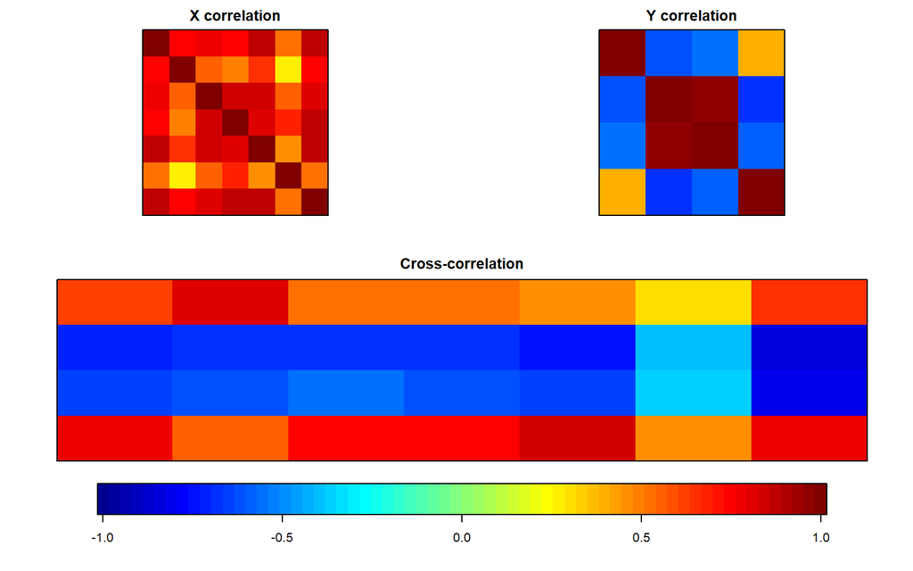

```r
img.matcor(correl.2, type = 2)
```

Como se puede observar en la matriz X, existe una fortísima correlación entre casi todas las variables. En la matriz y, también existen muy fuertes correlaciones, tanto lineales como inversas.

En la Cross-Correlation, interesa que no existan valores cercanos al cero. A excepción de la penúltima columna (0.3 y -0.3 aproximadamente), en el resto de celdas se ve que que los valores son muy distintos a cero.

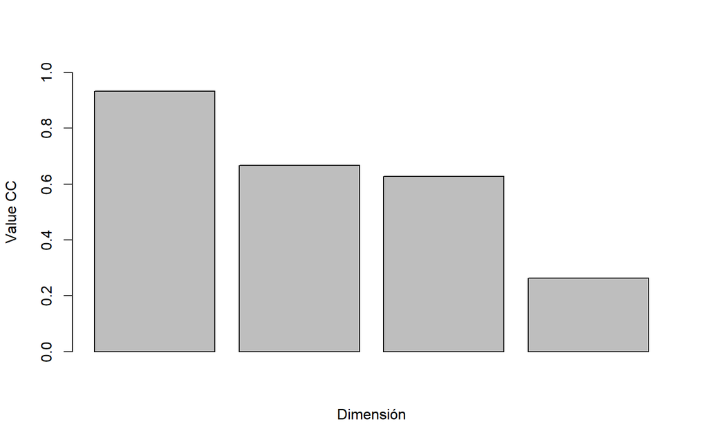

```r
cc.2 <- cc(matrizX, matrizY)
barplot(cc.2$cor, xlab = "Dimensión",
                  ylab = "Value CC",
                  ylim = c(0,1))
```

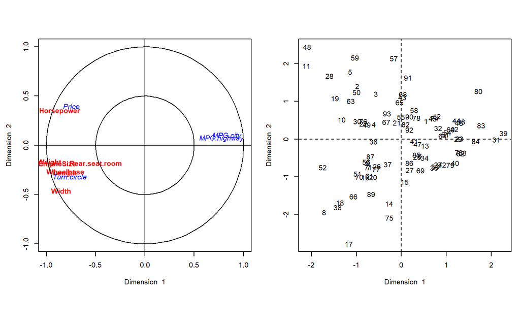

```r
plt.cc(cc.2, var.label = TRUE)
```

Como se puede observar, para la dimensión 1 los Miles Per Gallon son totalmente inversos a las variables usadas.